# Bike_Share_Analysis

THANKGOD AGADA

2022-09-15

##### Setting up my enviroment

To Load packages needed for importing data and getting comprehensive summary

```r
library(tidyverse)
library(readr)
library(skimr)
```

##### To Import files as Data frame using read.csv() function and assigning variables to each files

```r
DF_Jul_2021 <- read.csv("202107-divvy-tripdata_1.csv")
DF_Aug_2021 <- read.csv("202108-divvy-tripdata_1.csv")
DF_Sept_2021 <- read.csv("202109-divvy-tripdata_1.csv")
DF_Oct_2021 <- read.csv("202110-divvy-tripdata_1.csv")
DF_Nov_2021 <- read.csv("202111-divvy-tripdata_1.csv")
DF_Dec_2021 <- read.csv("202112-divvy-tripdata_1.csv")
DF_Jan_2022 <- read.csv("202201-divvy-tripdata_1.csv")
DF_Feb_2022 <- read.csv("202202-divvy-tripdata_1.csv")
DF_Mar_2022 <- read.csv("202203-divvy-tripdata_1.csv")
DF_Apr_2022 <- read.csv("202204-divvy-tripdata_1.csv")
DF_May_2022 <- read.csv("202205-divvy-tripdata_1.csv")
DF_June_2022 <- read.csv("202206-divvy-tripdata_1.csv")
```

##### To combine the data frames into one using bind_rows() function.

```r
Bike_rides <- bind_rows(DF_Jul_2021, DF_Aug_2021, DF_Sept_2021, DF_Oct_2021,
                        DF_Nov_2021, DF_Dec_2021, DF_Jan_2022, DF_Feb_2022,
                        DF_Mar_2022, DF_Apr_2022, DF_May_2022, DF_June_2022)
```

##### To understand the structure, shape and comprehensive summary of the dataset.

```r
head(Bike_rides)
```

```
##            ride_id rideable_type     started_at       ended_at
## 1 0A1B623926EF4E16   docked_bike 02-07-21 14:44 02-07-21 15:19
## 2 B2D5583A5A5E76EE  classic_bike 07-07-21 16:57 07-07-21 17:16
## 3 6F264597DDBF427A  classic_bike 25-07-21 11:30 25-07-21 11:48
## 4 379B58EAB20E8AA5  classic_bike 08-07-21 22:08 08-07-21 22:23
## 5 6615C1E4EB08E8FB electric_bike 28-07-21 16:08 28-07-21 16:27
## 6 62DC2B32872F9BA8 electric_bike 29-07-21 17:09 29-07-21 17:15
##             start_station_name start_station_id               end_station_name
## 1 Michigan Ave & Washington St            13001   Halsted St & North Branch St
## 2   California Ave & Cortez St            17660           Wood St & Hubbard St
## 3         Wabash Ave & 16th St           SL-012           Rush St & Hubbard St
## 4   California Ave & Cortez St            17660        Carpenter St & Huron St
## 5   California Ave & Cortez St            17660 Elizabeth (May) St & Fulton St
## 6   California Ave & Cortez St            17660  Albany Ave & Bloomingdale Ave
##   end_station_id start_lat start_lng  end_lat   end_lng member_casual
## 1   KA1504000117  41.88398 -87.62468 41.89937 -87.64848        casual
## 2          13432  41.90036 -87.69670 41.88990 -87.67147        casual
## 3   KA1503000044  41.86038 -87.62581 41.89017 -87.62619        member
## 4          13196  41.90036 -87.69670 41.89456 -87.65345        member
## 5          13197  41.90035 -87.69668 41.88659 -87.65839        casual
## 6          15655  41.90033 -87.69674 41.91389 -87.70513        casual
##   ride_length day_of_week
## 1     0:35:22           6
## 2     0:18:27           4
## 3     0:17:50           1
## 4     0:15:02           5
## 5     0:19:03           4
## 6     0:05:52           5
```

```r
tail(Bike_rides)
```

```
##                  ride_id rideable_type     started_at       ended_at
## 5900380 F1C4F671FE0FDDD1 electric_bike 26-06-22 19:50 26-06-22 19:55
## 5900381 7B3B2890CA85E05D  classic_bike  25-06-22 0:56  25-06-22 1:01
## 5900382 1E993989CC66BCBC  classic_bike  25-06-22 0:56  25-06-22 1:00
## 5900383 AEA166296BC67566 electric_bike 12-06-22 12:47 12-06-22 12:47
## 5900384 B9F527742959CF03  classic_bike 12-06-22 13:28 12-06-22 13:53
## 5900385 D241310352E26484  classic_bike 12-06-22 14:40 12-06-22 15:08
##                    start_station_name start_station_id
## 5900380    Clarendon Ave & Junior Ter            13389
## 5900381  Sheffield Ave & Kingsbury St            13154
## 5900382  Sheffield Ave & Kingsbury St            13154
## 5900383 Milwaukee Ave & Fullerton Ave              428
## 5900384        Clark St & Randolph St     TA1305000030
## 5900385     Blue Island Ave & 18th St            13135
##                      end_station_name end_station_id start_lat start_lng
## 5900380    Clarendon Ave & Junior Ter          13389  41.96100 -87.64946
## 5900381  Sheffield Ave & Kingsbury St          13154  41.91052 -87.65311
## 5900382  Sheffield Ave & Kingsbury St          13154  41.91052 -87.65311
## 5900383 Milwaukee Ave & Fullerton Ave            428  41.92000 -87.70000
## 5900384        Clark St & Randolph St   TA1305000030  41.88458 -87.63189
## 5900385     Blue Island Ave & 18th St          13135  41.85756 -87.66154
##          end_lat   end_lng member_casual ride_length day_of_week
## 5900380 41.96100 -87.64960        member     0:05:19           1
## 5900381 41.91052 -87.65311        member     0:04:51           7
## 5900382 41.91052 -87.65311        member     0:04:01           7
## 5900383 41.92000 -87.70000        casual     0:00:24           1
## 5900384 41.88458 -87.63189        casual     0:24:25           1
## 5900385 41.85756 -87.66154        casual     0:27:23           1
```

```r
glimpse(Bike_rides)
```

```
## Rows: 5,900,385
## Columns: 15
## $ ride_id            <chr> "0A1B623926EF4E16", "B2D5583A5A5E76EE", "6F264597DD…
## $ rideable_type      <chr> "docked_bike", "classic_bike", "classic_bike", "cla…
## $ started_at         <chr> "02-07-21 14:44", "07-07-21 16:57", "25-07-21 11:30…
## $ ended_at           <chr> "02-07-21 15:19", "07-07-21 17:16", "25-07-21 11:48…
## $ start_station_name <chr> "Michigan Ave & Washington St", "California Ave & C…
## $ start_station_id   <chr> "13001", "17660", "SL-012", "17660", "17660", "1766…
## $ end_station_name   <chr> "Halsted St & North Branch St", "Wood St & Hubbard …
## $ end_station_id     <chr> "KA1504000117", "13432", "KA1503000044", "13196", "…
## $ start_lat          <dbl> 41.88398, 41.90036, 41.86038, 41.90036, 41.90035, 4…
## $ start_lng          <dbl> -87.62468, -87.69670, -87.62581, -87.69670, -87.696…
## $ end_lat            <dbl> 41.89937, 41.88990, 41.89017, 41.89456, 41.88659, 4…
## $ end_lng            <dbl> -87.64848, -87.67147, -87.62619, -87.65345, -87.658…
## $ member_casual      <chr> "casual", "casual", "member", "member", "casual", "…
## $ ride_length        <chr> "0:35:22", "0:18:27", "0:17:50", "0:15:02", "0:19:0…
## $ day_of_week        <int> 6, 4, 1, 5, 4, 5, 4, 7, 6, 5, 2, 2, 6, 2, 4, 5, 6, …
```

```r
skim_without_charts(Bike_rides)
```

Data summary

| Name | Bike_rides |
| --- | --- |
| Number of rows | 5900385 |
| Number of columns | 15 |
| _______________________ |  |
| Column type frequency: |  |
| character | 10 |
| numeric | 5 |
| ________________________ |  |
| Group variables | None |

**Variable type: character**

| skim_variable | n_missing | complete_rate | min | max | empty | n_unique | whitespace |
| --- | --- | --- | --- | --- | --- | --- | --- |
| ride_id | 0 | 1 | 7 | 16 | 0 | 5900374 | 0 |
| rideable_type | 0 | 1 | 11 | 13 | 0 | 3 | 0 |
| started_at | 0 | 1 | 13 | 14 | 0 | 461895 | 0 |
| ended_at | 0 | 1 | 13 | 14 | 0 | 462575 | 0 |
| start_station_name | 0 | 1 | 0 | 64 | 836018 | 1294 | 0 |
| start_station_id | 0 | 1 | 0 | 44 | 836015 | 1157 | 0 |
| end_station_name | 0 | 1 | 0 | 64 | 892103 | 1316 | 0 |
| end_station_id | 0 | 1 | 0 | 44 | 892103 | 1171 | 0 |
| member_casual | 0 | 1 | 6 | 6 | 0 | 2 | 0 |
| ride_length | 0 | 1 | 7 | 255 | 0 | 23615 | 0 |

**Variable type: numeric**

| skim_variable | n_missing | complete_rate | mean | sd | p0 | p25 | p50 | p75 | p100 |
| --- | --- | --- | --- | --- | --- | --- | --- | --- | --- |
| start_lat | 0 | 1 | 41.90 | 0.05 | 41.64 | 41.88 | 41.90 | 41.93 | 45.64 |
| start_lng | 0 | 1 | -87.65 | 0.03 | -87.84 | -87.66 | -87.64 | -87.63 | -73.80 |
| end_lat | 5374 | 1 | 41.90 | 0.05 | 41.39 | 41.88 | 41.90 | 41.93 | 42.17 |
| end_lng | 5374 | 1 | -87.65 | 0.03 | -88.97 | -87.66 | -87.64 | -87.63 | -87.49 |
| day_of_week | 0 | 1 | 4.09 | 2.04 | 1.00 | 2.00 | 4.00 | 6.00 | 7.00 |

```r
str(Bike_rides)
```

```
## 'data.frame':    5900385 obs. of  15 variables:
##  $ ride_id           : chr  "0A1B623926EF4E16" "B2D5583A5A5E76EE" "6F264597DDBF427A" "379B58EAB20E8AA5" ...
##  $ rideable_type     : chr  "docked_bike" "classic_bike" "classic_bike" "classic_bike" ...
##  $ started_at        : chr  "02-07-21 14:44" "07-07-21 16:57" "25-07-21 11:30" "08-07-21 22:08" ...
##  $ ended_at          : chr  "02-07-21 15:19" "07-07-21 17:16" "25-07-21 11:48" "08-07-21 22:23" ...
##  $ start_station_name: chr  "Michigan Ave & Washington St" "California Ave & Cortez St" "Wabash Ave & 16th St" "California Ave & Cortez St" ...
##  $ start_station_id  : chr  "13001" "17660" "SL-012" "17660" ...
##  $ end_station_name  : chr  "Halsted St & North Branch St" "Wood St & Hubbard St" "Rush St & Hubbard St" "Carpenter St & Huron St" ...
##  $ end_station_id    : chr  "KA1504000117" "13432" "KA1503000044" "13196" ...
##  $ start_lat         : num  41.9 41.9 41.9 41.9 41.9 ...
##  $ start_lng         : num  -87.6 -87.7 -87.6 -87.7 -87.7 ...
##  $ end_lat           : num  41.9 41.9 41.9 41.9 41.9 ...
##  $ end_lng           : num  -87.6 -87.7 -87.6 -87.7 -87.7 ...
##  $ member_casual     : chr  "casual" "casual" "member" "member" ...
##  $ ride_length       : chr  "0:35:22" "0:18:27" "0:17:50" "0:15:02" ...
##  $ day_of_week       : int  6 4 1 5 4 5 4 7 6 5 ...
```

##### DATA PROCESSING

Here, I loaded packages needed for data wrangling

```r
library(dplyr)
library(tidyr)
library(lubridate)
library(janitor)
```

##### To change the datatypes of started_at, ended_at and ride_length columns

Here, i formatted the datatypes from character to date and time respectively

```r
Bike_rides$started_at <- lubridate::dmy_hm(Bike_rides$started_at)
Bike_rides$ended_at <- lubridate::dmy_hm(Bike_rides$ended_at)
Bike_rides[['ride_length']] <- as.POSIXct(Bike_rides[['ride_length']],
                                          format = "%H:%M:%S")
```

##### To removed rows with blanks or empty spaces from end_station_name and end_station_id

```r
Bike_rides = Bike_rides[Bike_rides$end_station_name != "", ]
```

##### To explore and remove NA in the dataset

Here, I checked for NAs and removed them

```r
colSums(is.na(Bike_rides))
```

```
##            ride_id      rideable_type         started_at           ended_at
##                  0                  0                  0                  0
## start_station_name   start_station_id   end_station_name     end_station_id
##                  0                  0                  0                  0
##          start_lat          start_lng            end_lat            end_lng
##                  0                  0                  0                  0
##      member_casual        ride_length        day_of_week
##                  0                121                  0
```

```r
sum(is.na(Bike_rides))
```

```
## [1] 121
```

```r
Bike_rides <- na.omit(Bike_rides)
```

##### To split date-time columns into two separate columns (date & time) in started_at, ended_at and ride_length columns.

Here, I splitted the columns that has both date and time into two seperate columns, date and time

```r
Bike_rides <- separate(Bike_rides, "started_at", into=c('start_date',
                                                        'start_time'), sep = ' ')
Bike_rides <- separate(Bike_rides, "ended_at", into=c('end_date',
                                                      'end_time'), sep = ' ')
Bike_rides <- separate(Bike_rides, "ride_length", into=c('ride_length_date',
                                                        'ride_length_time'), sep=' ')
```

##### To Make the columns consistent by renaming it using rename() function

```r
Bike_rides <- Bike_rides %>%
  rename(bike_type = rideable_type,
         user_type = member_casual)
```

##### To convert start_date and ride_length_time from character to its respective datatypes

```r
Bike_rides$start_date <- lubridate::as_date(Bike_rides$start_date)
Bike_rides$ride_length_time<- lubridate::hms(Bike_rides$ride_length_time)
```

##### To have weekday in letters. Created a new variables ’day_of_week_1 using weekdays() function.

Here, I created a new column to have the weekdays in letters as opposed to numbers.

```r
Bike_rides$day_of_week_1 <- weekdays(Bike_rides$start_date)
```

```r
Bike_rides <- Bike_rides %>%
  filter(ride_length_time > 0)
```

##### DATA_ANALYSIS

###### 1.To calculate Mean ride_length

```r
Bike_rides %>%
  summarize(Average_Ride = mean(ride_length_time))
```

```
##   Average_Ride
## 1     29.40222
```

###### 2. Ride Summary(Mean, Min, Max)

```r
Bike_rides %>%
  group_by(user_type) %>%
  summarise(Average_ride_time = mean(ride_length_time),
            Max_ride_time = max(ride_length_time),
            Min_ride_time = min(ride_length_time))
```

```
## # A tibble: 2 × 4
##   user_type Average_ride_time Max_ride_time Min_ride_time
##   <chr>                 <dbl>         <dbl>         <dbl>
## 1 casual                 29.4            59             0
## 2 member                 29.4            59             0
```

###### 3. To analyze the Mode of day of week

Here, I Defined a function used to calcaulate the Mode

```r
Mode <- function(x) {
  uniqx <- unique(x)
  uniqx[which.max(tabulate(match(x, uniqx)))] }

x = Bike_rides$day_of_week_1
y <- Mode(x)
print(y)
```

```
## [1] "Saturday"
```

###### Alternatively

```r
names(sort(-table(Bike_rides$day_of_week_1)))[1]
```

```
## [1] "Saturday"
```

###### 4. To calculate the average ride_length for members and casual riders.

```r
Bike_rides %>%
  group_by(user_type) %>%
  summarise(Average_ride_length = mean(ride_length_time))
```

```
## # A tibble: 2 × 2
##   user_type Average_ride_length
##   <chr>                   <dbl>
## 1 casual                   29.4
## 2 member                   29.4
```

###### 5. To calculate the average ride_length for users by day_of_week.

```r
Bike_rides %>% #[Not done yet]
  group_by(user_type, day_of_week_1) %>%
  summarize(Average_ride_length = mean(ride_length_time)) %>%
  arrange(day_of_week_1)
```

```
## # A tibble: 14 × 3
## # Groups:   user_type [2]
##    user_type day_of_week_1 Average_ride_length
##    <chr>     <chr>                       <dbl>
##  1 casual    Friday                       29.4
##  2 member    Friday                       29.4
##  3 casual    Monday                       29.4
##  4 member    Monday                       29.4
##  5 casual    Saturday                     29.4
##  6 member    Saturday                     29.4
##  7 casual    Sunday                       29.4
##  8 member    Sunday                       29.4
##  9 casual    Thursday                     29.5
## 10 member    Thursday                     29.4
## 11 casual    Tuesday                      29.4
## 12 member    Tuesday                      29.4
## 13 casual    Wednesday                    29.4
## 14 member    Wednesday                    29.3
```

###### 6.To analyze the number of rides for users by day_of_week

```r
Bike_rides %>%
  group_by(user_type, day_of_week_1) %>%
  summarise(Number_of_rides = n())
```

```
## # A tibble: 14 × 3
## # Groups:   user_type [2]
##    user_type day_of_week_1 Number_of_rides
##    <chr>     <chr>                   <int>
##  1 casual    Friday                 300280
##  2 casual    Monday                 252142
##  3 casual    Saturday               461940
##  4 casual    Sunday                 401235
##  5 casual    Thursday               266923
##  6 casual    Tuesday                225818
##  7 casual    Wednesday              232570
##  8 member    Friday                 399046
##  9 member    Monday                 403811
## 10 member    Saturday               379289
## 11 member    Sunday                 340152
## 12 member    Thursday               451410
## 13 member    Tuesday                447538
## 14 member    Wednesday              445866
```

###### 7. To analyze the number of rides for users

```r
Bike_rides %>%
  group_by(user_type) %>%
  summarise(Number_of_Rides = n()) %>%
  arrange(desc(Number_of_Rides))
```

```
## # A tibble: 2 × 2
##   user_type Number_of_Rides
##   <chr>               <int>
## 1 member            2867112
## 2 casual            2140908
```

###### 8.To analyze the number of rides for users per season

```r
Bike_rides %>%
  group_by(user_type, Season = case_when(
    month(lubridate::as_date(start_date)) == 12 ~ 'Winter',
    month(lubridate::as_date(start_date)) == 01 ~ 'Winter',
    month(lubridate::as_date(start_date)) == 02 ~ 'Winter',
    month(lubridate::as_date(start_date)) == 03 ~ 'Spring',
    month(lubridate::as_date(start_date)) == 04 ~ 'Spring',
    month(lubridate::as_date(start_date)) == 05 ~ 'Spring',
    month(lubridate::as_date(start_date)) == 06 ~ 'Summer',
    month(lubridate::as_date(start_date)) == 07 ~ 'Summer',
    month(lubridate::as_date(start_date)) == 08 ~ 'Summer',
    TRUE ~ ' Fall')) %>%
  summarize(Number_of_rides = n()) %>%
  arrange(Season)
```

```
## # A tibble: 8 × 3
## # Groups:   user_type [2]
##   user_type Season   Number_of_rides
##   <chr>     <chr>              <int>
## 1 casual    " Fall"           592360
## 2 member    " Fall"           861613
## 3 casual    "Spring"          407377
## 4 member    "Spring"          663101
## 5 casual    "Summer"         1060600
## 6 member    "Summer"         1047836
## 7 casual    "Winter"           80571
## 8 member    "Winter"          294562
```

###### 9. To analyze the number of rides per month

```r
Bike_rides %>%
  group_by(user_type, Month = case_when(
    month(lubridate::as_date(start_date)) == 01 ~ 'Jan',
    month(lubridate::as_date(start_date)) == 02 ~ 'Feb',
    month(lubridate::as_date(start_date)) == 03 ~ 'Mar',
    month(lubridate::as_date(start_date)) == 04 ~ 'April',
    month(lubridate::as_date(start_date)) == 05 ~ 'May',
    month(lubridate::as_date(start_date)) == 06 ~ 'June',
    month(lubridate::as_date(start_date)) == 07 ~ 'July',
    month(lubridate::as_date(start_date)) == 08 ~ 'Aug',
    month(lubridate::as_date(start_date)) == 09 ~ 'Sept',
    month(lubridate::as_date(start_date)) == 10 ~ 'Oct',
    month(lubridate::as_date(start_date)) == 11 ~ 'Nov',
    TRUE ~ ' Dec')) %>%
  summarize(Number_of_rides = n()) %>%
  arrange(desc(Number_of_rides))
```

```
## # A tibble: 24 × 3
## # Groups:   user_type [2]
##    user_type Month Number_of_rides
##    <chr>     <chr>           <int>
##  1 casual    July           387718
##  2 casual    Aug            358837
##  3 member    June           354964
##  4 member    Aug            351367
##  5 member    Sept           346957
##  6 member    July           341505
##  7 casual    June           314045
##  8 member    Oct            311786
##  9 casual    Sept           309878
## 10 member    May            305868
## # … with 14 more rows
```

###### 10. To analyze the most preferred time_of_day

```r
Bike_rides %>%
  group_by(user_type, time_of_day = case_when(
    start_time >= "06:00" & start_time <= "12:00" ~ "Morning",
    start_time >= "12:00" & start_time <= "16:00" ~ "Afternoon",
    start_time >= "16:00" & start_time <= "19:00" ~ "Evening",
    TRUE ~ "Night")) %>%
  summarize(Number_of_rides = n()) %>%
  arrange(desc(Number_of_rides))
```

```
## # A tibble: 8 × 3
## # Groups:   user_type [2]
##   user_type time_of_day Number_of_rides
##   <chr>     <chr>                 <int>
## 1 member    Evening              802624
## 2 member    Morning              801454
## 3 member    Afternoon            657986
## 4 member    Night                605048
## 5 casual    Afternoon            591899
## 6 casual    Night                588203
## 7 casual    Evening              563810
## 8 casual    Morning              396996
```

###### 11. To analyze the most preferred bike type

```r
Bike_rides %>%
  group_by(bike_type) %>%
  summarize(Number_of_usage = n()) %>%
  #arrange(desc(Number_of_usage)) %>%
  mutate(percentage = round(Number_of_usage/sum(Number_of_usage),4) * 100,
         lab.pos = cumsum(percentage) -0.5*percentage)
```

```
## # A tibble: 3 × 4
##   bike_type     Number_of_usage percentage lab.pos
##   <chr>                   <int>      <dbl>   <dbl>
## 1 classic_bike          3181712      63.5     31.8
## 2 docked_bike            252046       5.03    66.0
## 3 electric_bike         1574262      31.4     84.3
```

##### DATA VISUALIZATION

Explorative data Analysis was performed to find patterns and relationships.

###### To load packages needed for data visualization

```r
library(scales)
library(ggpubr)
library(ggsci)
library(viridis)
library(RColorBrewer)
library(ggrepel)
```

###### To view the number of rides for users by day_of_week

Here, I plotted Number of rides against day of week

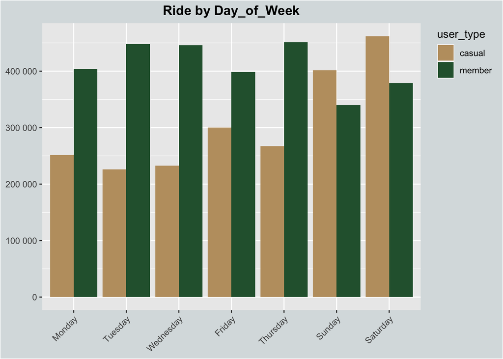

```r
Bike_rides %>%
  group_by(user_type, day_of_week_1) %>%
  summarise(Number_of_rides = n()) %>%
  ggplot(aes(reorder(day_of_week_1, Number_of_rides), Number_of_rides, fill = user_type))+
  geom_bar(position = 'dodge', stat = 'identity') +
  labs(title = "Ride by Day_of_Week") +
  theme(panel.spacing = unit(4, "lines"),
        axis.text.x=element_text(angle=45, hjust=1)) +
  scale_fill_manual(values = c("casual" = "#BE9E6F",
                               "member" = "#2A603B")) +
  theme(legend.justification = c("right", "top")) +
  theme(legend.background = element_rect(fill="#D9DFE0",
                                         size=0.5, linetype="solid")) +
  theme(plot.background = element_rect(fill = "#D9DFE0")) +
  theme(axis.title.x = element_blank(),
        axis.title.y = element_blank()) +
  theme(plot.title = element_text(hjust = 0.5)) +
  theme(plot.title = element_text(face = "bold")) +
  scale_y_continuous(labels = number)
```

###### To view ride distribution, i.e, the number of rides for users

Here, I plotted a piechart to see the percentage of casual and member’s riders

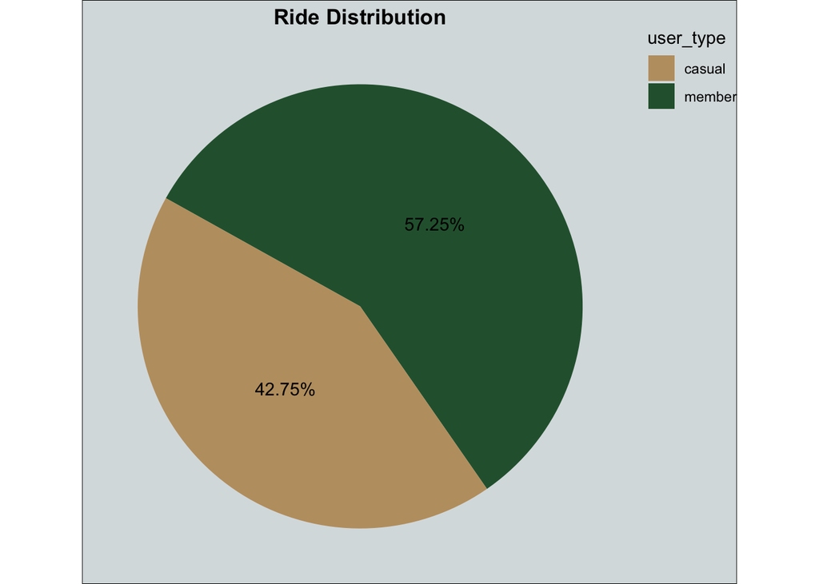

```r
Pie = Bike_rides %>%
  group_by(user_type) %>%
  summarise(Number_of_Rides = n()) %>%
  ungroup() %>%
  arrange(desc(Number_of_Rides)) %>%
  mutate(percentage = round(Number_of_Rides/sum(Number_of_Rides),4) * 100,
         lab.pos = cumsum(percentage) -0.5*percentage)

ggplot(data = Pie,
       aes(x = "", y = percentage, fill = user_type)) +
  geom_bar(stat = "identity") + #Plot a stack bar chart
  coord_polar("y", start = 200) +
  geom_text(aes(y = lab.pos, label = paste(percentage, "%", sep = ""))
            , col = "black") +
  ggtitle("Ride Distribution") +
  theme_void() +
  theme(plot.background = element_rect(fill = "#D9DFE0")) +
  theme(plot.title = element_text(hjust = 0.5)) +
  theme(plot.title = element_text(face = "bold")) +
  theme(legend.justification = c("right", "top")) +
  scale_fill_manual(values = c("#BE9E6F", "#2A603B"))
```

###### To View it in donuts

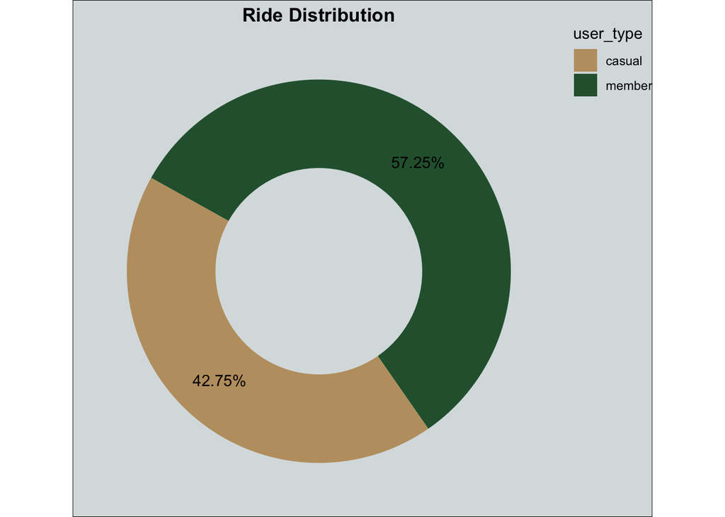

```r
Donut = Bike_rides %>%
  group_by(user_type) %>%
  summarise(Number_of_Rides = n()) %>%
  ungroup() %>%
  arrange(desc(Number_of_Rides)) %>%
  mutate(percentage = round(Number_of_Rides/sum(Number_of_Rides),4) * 100,
         lab.pos = cumsum(percentage) -0.5*percentage)

ggplot(data = Donut,
       aes(x =2, y = percentage, fill = user_type)) +
  geom_bar(stat = "identity") +
  coord_polar("y", start = 200) +
  geom_text(aes(y = lab.pos, label = paste(percentage, "%",
                                           sep = "")), col = "black") +
  ggtitle("Ride Distribution") +
  theme_void() +
  theme(legend.justification = c("right", "top")) +
  scale_fill_manual(values = c("#BE9E6F", "#2A603B")) +
  xlim(0.5, 2.5) +
  theme(plot.title = element_text(hjust = 0.5)) +
  theme(plot.title = element_text(face = "bold")) +
  theme(plot.background = element_rect(fill = "#D9DFE0"))
```

###### To view the number of rides per season

Here, I plotted Number of rides against season

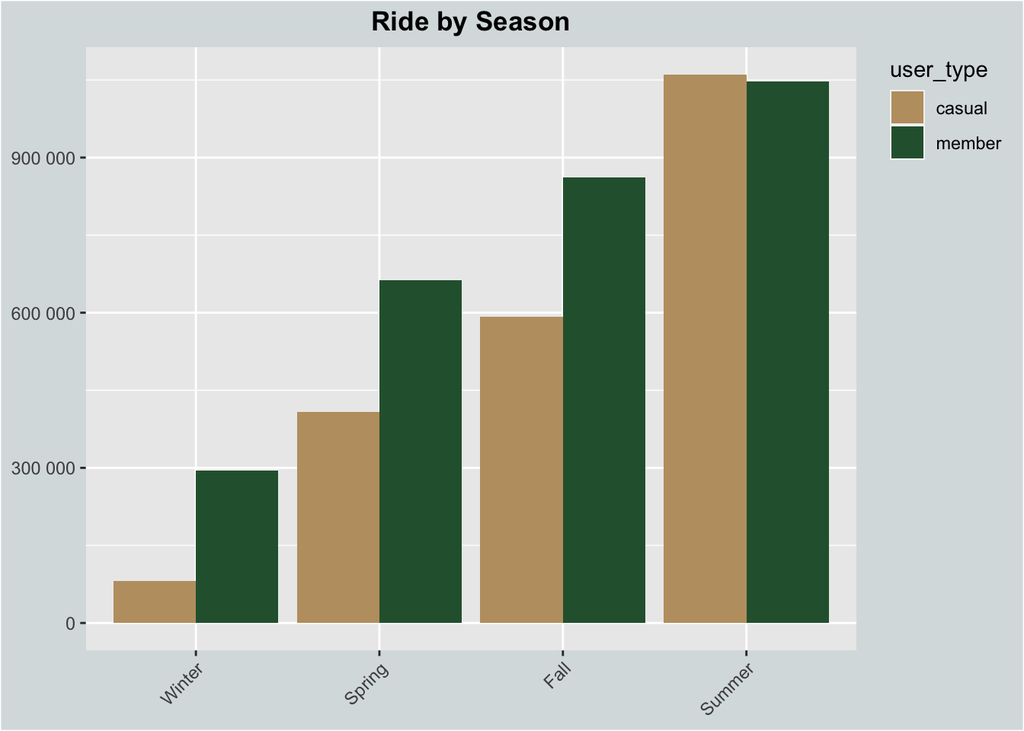

```r
Bike_rides %>%
  group_by(user_type, Season = case_when(
    month(lubridate::as_date(start_date)) == 12 ~ 'Winter',
    month(lubridate::as_date(start_date)) == 01 ~ 'Winter',
    month(lubridate::as_date(start_date)) == 02 ~ 'Winter',
    month(lubridate::as_date(start_date)) == 03 ~ 'Spring',
    month(lubridate::as_date(start_date)) == 04 ~ 'Spring',
    month(lubridate::as_date(start_date)) == 05 ~ 'Spring',
    month(lubridate::as_date(start_date)) == 06 ~ 'Summer',
    month(lubridate::as_date(start_date)) == 07 ~ 'Summer',
    month(lubridate::as_date(start_date)) == 08 ~ 'Summer',
    TRUE ~ ' Fall')) %>%
  summarize(Number_of_rides = n()) %>%
  ggplot(aes(reorder(Season, Number_of_rides), Number_of_rides, fill = user_type))+
  geom_bar(position = 'dodge', stat = 'identity') +
  labs(title = "Ride by Season") +
  theme(panel.spacing = unit(4, "lines"),
        axis.text.x=element_text(angle=45, hjust=1)) +
  scale_fill_manual(values = c("casual" = "#BE9E6F",
                               "member" = "#2A603B")) +
  theme(legend.justification = c("right", "top")) +
  theme(legend.background = element_rect(fill="#D9DFE0",
                                         size=0.5, linetype="solid")) +
  theme(plot.background = element_rect(fill = "#D9DFE0")) +
  theme(axis.title.x = element_blank(),
        axis.title.y = element_blank()) +
  theme(plot.title = element_text(hjust = 0.5)) +
  theme(plot.title = element_text(face = "bold")) +
  scale_y_continuous(labels = number)
```

###### To view the number of rides per month

Here, I plotted Number of rides against month

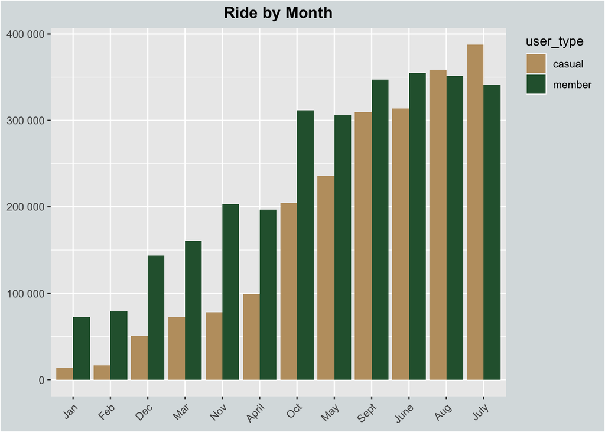

```r
Bike_rides %>%
  group_by(user_type, Month = case_when(
    month(lubridate::as_date(start_date)) == 01 ~ 'Jan',
    month(lubridate::as_date(start_date)) == 02 ~ 'Feb',
    month(lubridate::as_date(start_date)) == 03 ~ 'Mar',
    month(lubridate::as_date(start_date)) == 04 ~ 'April',
    month(lubridate::as_date(start_date)) == 05 ~ 'May',
    month(lubridate::as_date(start_date)) == 06 ~ 'June',
    month(lubridate::as_date(start_date)) == 07 ~ 'July',
    month(lubridate::as_date(start_date)) == 08 ~ 'Aug',
    month(lubridate::as_date(start_date)) == 09 ~ 'Sept',
    month(lubridate::as_date(start_date)) == 10 ~ 'Oct',
    month(lubridate::as_date(start_date)) == 11 ~ 'Nov',
    TRUE ~ ' Dec')) %>%
  summarize(Number_of_rides = n()) %>%
  ggplot(aes(reorder(Month, Number_of_rides), Number_of_rides, fill = user_type))+
  geom_bar(position = 'dodge', stat = 'identity') +
  labs(title = "Ride by Month") +
  theme(panel.spacing = unit(4, "lines"),
        axis.text.x=element_text(angle=45, hjust=1)) +
  scale_fill_manual(values = c("casual" = "#BE9E6F",
                               "member" = "#2A603B")) +
  theme(legend.justification = c("right", "top")) +
  theme(legend.background = element_rect(fill="#D9DFE0",
                                         size=0.5, linetype="solid")) +
  theme(plot.background = element_rect(fill = "#D9DFE0")) +
  theme(axis.title.x = element_blank(),
        axis.title.y = element_blank()) +
  theme(plot.title = element_text(hjust = 0.5)) +
  theme(plot.title = element_text(face = "bold")) +
  scale_y_continuous(labels = number)
```

###### To view the most preferred time of day

Here, I plotted Number of rides against Time of day

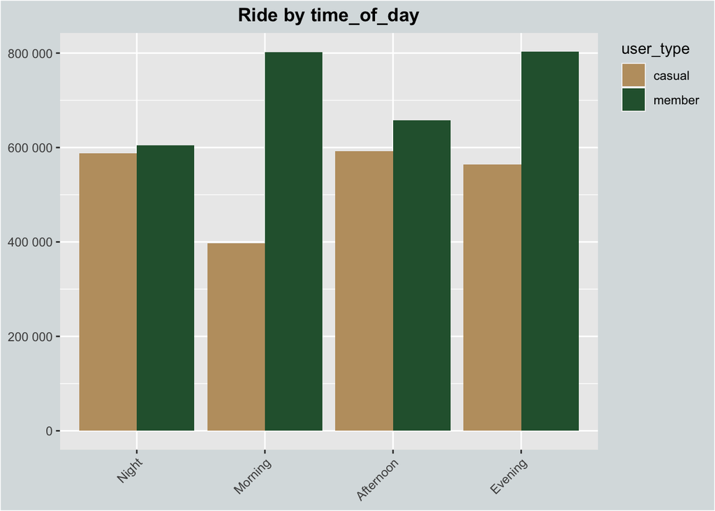

```r
Bike_rides %>%
  group_by(user_type, time_of_day = case_when(
    start_time >= "06:00" & start_time <= "12:00" ~ "Morning",
    start_time >= "12:00" & start_time <= "16:00" ~ "Afternoon",
    start_time >= "16:00" & start_time <= "19:00" ~ "Evening",
    TRUE ~ "Night")) %>%
  summarize(Number_of_rides = n()) %>%
  arrange(desc(Number_of_rides)) %>%
  ggplot(aes(reorder(time_of_day, Number_of_rides), Number_of_rides, fill = user_type))+
  geom_bar(position = 'dodge', stat = 'identity') +
  labs(title = "Ride by time_of_day") +
  theme(panel.spacing = unit(4, "lines"),
        axis.text.x=element_text(angle=45, hjust=1)) +
  scale_fill_manual(values = c("casual" = "#BE9E6F",
                               "member" = "#2A603B")) +
  theme(legend.justification = c("right", "top")) +
  theme(legend.background = element_rect(fill="#D9DFE0",
                                         size=0.5, linetype="solid")) +
  theme(plot.background = element_rect(fill = "#D9DFE0")) +
  theme(axis.title.x = element_blank(),
        axis.title.y = element_blank()) +
  theme(plot.title = element_text(hjust = 0.5)) +
  theme(plot.title = element_text(face = "bold")) +
  scale_y_continuous(labels = number)
```

###### To view the most preferred bike type

Here, I plotted a donut to see the most preffered bike type

[figure not shown]

```r
Bike_rides %>%
  group_by(bike_type) %>%
  summarize(Number_of_usage = n()) %>%
  arrange(desc(Number_of_usage)) %>%
  mutate(percentage = round(Number_of_usage/sum(Number_of_usage),4) * 100,
         lab.pos = cumsum(percentage) -0.5*percentage) %>%
  ggplot(aes(x =2, y = percentage, fill = bike_type)) +
  geom_bar(stat = "identity") +
  coord_polar("y", start = 200) +
  #geom_text(aes(y = lab.pos, label = paste(percentage, "%",
  #sep = "")), col = "black") +
  ggtitle("Bike_type Preference") +
  theme_void() +
  theme(legend.justification = c("right", "top")) +
  scale_fill_manual(values = c("#BE9E6F", "#568203", "#05472a")) +
  xlim(0.5, 2.5) + # 0.5 = hsize. smaller d num bigger d hsize
  theme(plot.title = element_text(hjust = 0.5)) +
  theme(plot.title = element_text(face = "bold")) +
  theme(plot.background = element_rect(fill = "#D9DFE0"))+
  theme(legend.key = element_rect(fill = "black", colour = "black"))+
  geom_text(aes(label = paste(percentage, "%", sep = "")),
            position = position_stack(vjust = 0.5), col = "white")+
  geom_label_repel(aes(label = Number_of_usage), col = "white",
                   size = 3.5, nudge_x = 1.5, show.legend = FALSE)
```